# Final Project

Alice Cline

2023-11-28

# Introduction

In 2010, the passage of the Affordable Care Act enabled states to decide whether to enact Medicaid Expansion. These expansions enabled states to offer Medicaid coverage to a wider range of poor adults, families, and children.

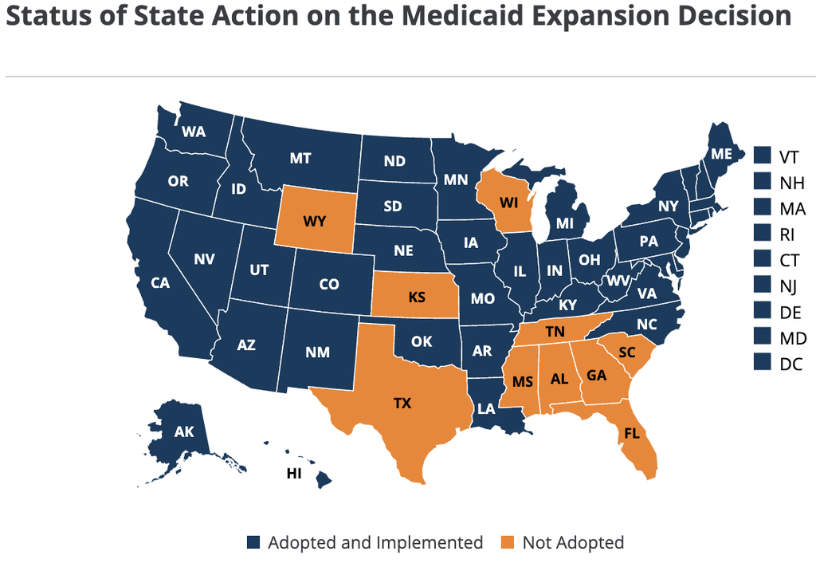

Note: this image includes 6 states in blue that adopted ME between 2020-2023 and are not included in my Expansion states category.

## Description of the problem

While it’s easy to see improvements in insurance coverage in Expansion states after they enacted Medicaid Expansion, it’s more difficult to determine whether Medicaid Expansion led to improvements in prenatal care or pregnancy outcomes for women in those states.

The image below demostrates that rates of uninsurance among pregnant women in Expansion states (blue) is significantly lower than in non-Expansion states (orange).

[figure not shown]

The image above is copied from an article by U. Ranji et al., linked [here](https://www.kff.org/womens-health-policy/issue-brief/loss-of-the-aca-could-greatly-erode-health-coverage-and-benefits-for-women/).

## Research question & Methods

I propose to answer this question:

**Are insurance coverage rates and maternal health care utilization better in states that expanded Medicaid?**

Using data from the CDC Pregnancy Risk Assessment Monitoring Survey (PRAMS) from 2020, I will compare participants in states that did and did not expand Medicaid by 2020. I will use logistic regression to determine if there are differences in uninsurance rates (before, during, and after pregnancy) and maternal health care utilization (adequate prenatal care measured by the Kessner Index and attendance at a postpartum visit).

The PRAMS data set surveys women 2-4 months after the birth of their child and asks numerous questions about their care before, during, and after pregnancy. The variables of interest in this analysis are:

- **Independent variable:** Naturally occurring policy change - Medicaid Expansion
- **Dependent variables:**
  - *Uninsurance rates:* Before pregnancy, During pregnancy, Postpartum (after delivery)
  - *Maternal health care utilization:* Adequate prenatal care, Attendance at a postpartum visit

## Table of states with date of Medicaid Expansion

Note: since 2020, several more states (Missouri, Nebraska, North Carolina, Oklahoma, South Dakota, Utah) have adopted Medicaid Expansion, but since participants in these states will not have benefitted from the change in policies by the time of data collection, they are included in the “Non-Expansion group”.

Medicaid Expansion States by Year

| State | Adopted ME | Year |
| --- | --- | --- |
| Alabama | no | 0 |
| Alaska | yes | 2015 |
| Arizona | yes | 2014 |
| Arkansas | yes | 2014 |
| California | yes | 2014 |
| Colorado | yes | 2014 |
| Connecticut | yes | 2014 |
| Delaware | yes | 2014 |
| Florida | no | 0 |
| Georgia | no | 0 |
| Hawaii | yes | 2014 |
| Idaho | yes | 2020 |
| Illinois | yes | 2014 |
| Indiana | yes | 2015 |
| Iowa | yes | 2014 |
| Kansas | no | 0 |
| Kentucky | yes | 2014 |
| Louisiana | yes | 2016 |
| Maine | yes | 2018 |
| Maryland | yes | 2014 |
| Massachussets | yes | 2014 |
| Michigan | yes | 2014 |
| Minnisota | yes | 2014 |
| Mississippi | no | 0 |
| Missouri | no | 0 |
| Montana | yes | 2016 |
| Nebraska | no | 0 |
| Nevada | yes | 2014 |
| New Hampshire | yes | 2014 |
| New Jersey | yes | 2014 |
| New Mexico | yes | 2014 |
| New York | yes | 2014 |
| North Carolina | no | 0 |
| North Dakota | yes | 2014 |
| Ohio | yes | 2014 |
| Oklahoma | no | 0 |
| Oregon | yes | 2014 |
| Pennsylvania | yes | 2015 |
| Rhode Island | yes | 2014 |
| South Carolina | no | 0 |
| South Dakota | no | 0 |
| Tennessee | no | 0 |
| Texas | no | 0 |
| Utah | no | 0 |
| Vermont | yes | 2014 |
| Virginia | yes | 2018 |
| Washington | yes | 2014 |
| West Virginia | yes | 2014 |
| Wisconsin | no | 0 |
| Wyoming | no | 0 |

# Set up dataset

I used the following steps to prepare my data

- Load PRAMS dataset
- Retain only the relevant variables:
  - State of residence during birth
  - Sociodemographic factors of the mother: RaceEth, age, education, WIC, married
  - Insurance status at 3 time points
  - Adequate prenatal care and Attendance at a postpartum visit
- Mutate variables to improve interpretation
  - Create variable for state Medicaid Expansion status
  - Create variable for any point of uninsurance in perinatal period
  - Create variable for full maternal care utilization in perinatal period

# Results

## Descriptive statistics

This table compares the sociodemographic characteristics of the women who delivered in Expansion versus Non-Expansion states.

| **Characteristic** | **Overall**, N = 86,899 | **Medicaid Expansion Status** **Non-Expansion State** | **Medicaid Expansion Status** **Expansion State** | **p-value**<sup>1</sup> |  |
| --- | --- | --- | --- | --- | --- |
| Age in years, No. (%) |  |  |  |  | <0.001 |
| <17 | 967 (1.1%) | 358 (1.4%) | 609 (1.0%) |  |  |
| >40 | 3,286 (3.8%) | 780 (3.0%) | 2,506 (4.1%) |  |  |
| 18-19 | 2,675 (3.1%) | 946 (3.6%) | 1,729 (2.8%) |  |  |
| 20-24 | 15,282 (18%) | 5,220 (20%) | 10,062 (17%) |  |  |
| 25-29 | 24,583 (28%) | 7,903 (30%) | 16,680 (27%) |  |  |
| 30-34 | 26,119 (30%) | 7,323 (28%) | 18,796 (31%) |  |  |
| 35-39 | 13,981 (16%) | 3,478 (13%) | 10,503 (17%) |  |  |
| Race & Ethnicity, No. (%) |  |  |  | <0.001 |  |
| Black non-Hispanic | 15,157 (19%) | 5,092 (21%) | 10,065 (18%) |  |  |
| Hispanic | 15,688 (20%) | 4,113 (17%) | 11,575 (21%) |  |  |
| other race non-Hispanic | 10,632 (13%) | 2,656 (11%) | 7,976 (14%) |  |  |
| White non-Hispanic | 38,836 (48%) | 12,840 (52%) | 25,996 (47%) |  |  |
| Marital Status (yes), No. (%) | 51,059 (59%) | 15,075 (58%) | 35,984 (59%) | 0.002 |  |
| WIC enrollment (yes), No. (%) | 30,635 (36%) | 9,375 (36%) | 21,260 (35%) | 0.004 |  |
| Education Level, No. (%) |  |  |  | <0.001 |  |
| college grad | 30,864 (36%) | 7,986 (31%) | 22,878 (38%) |  |  |
| HS grad | 20,977 (24%) | 6,959 (27%) | 14,018 (23%) |  |  |
| less than HS | 9,847 (11%) | 3,172 (12%) | 6,675 (11%) |  |  |
| some college | 24,532 (28%) | 7,683 (30%) | 16,849 (28%) |  |  |

<sup>1</sup> Pearson’s Chi-squared test

## Rates of Insurance Continuity and Maternal Healthcare Utilization

These figures compares insurance continuity and maternal health care utlization at two points (adequate prenatal care measured by the Kessner Index and attendance at a postpartum appointment) for women living in states that did and did NOT expand Medicaid.

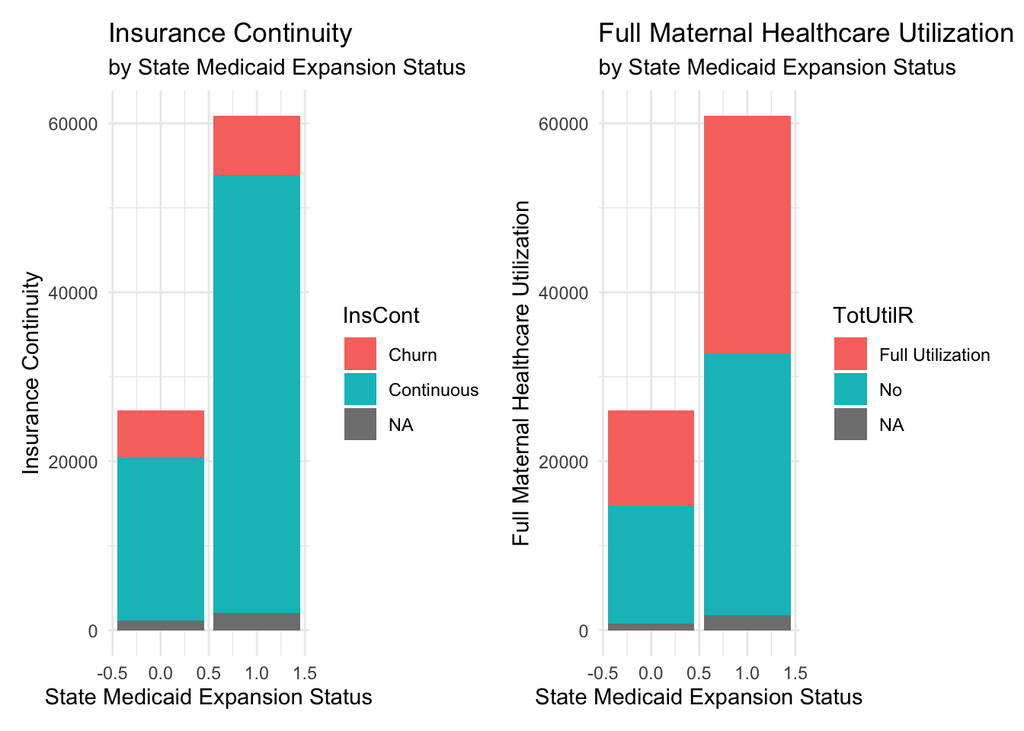

## Contingency tables

The tables below are Frequency tables of **full maternal care utilization** and **uninsurance rates** by state Medicaid Expansion status.

First, **Full Maternal Healthcare Utilization** by state Medicaid expansion status:

Comparison of Maternal Healthcare Utilization Rates by State Medicaid Expansion Status

[output not shown]

Pearson’s Chi-squared test, p<0.001

Next, **Insurance Continuity** by state Medicaid expansion status:

Comparison of Insurance Continuity Rates by State Medicaid Expansion Status

|  | **Insurance Continuity** **No** | **Insurance Continuity** **Yes** |
| --- | --- | --- |
| State Medicaid Expansion Status |  |  |
| no | 5,499 (22%) | 19,406 (78%) |
| yes | 6,989 (12%) | 51,901 (88%) |
| Total | 12,488 (15%) | 71,307 (85%) |

Pearson’s Chi-squared test, p<0.001

## Logistic regression

Is Medicaid Expansion associated with differences in insurance continuity and maternal healthcare utilization for pregnant women?

Comparison of Insurance Continuity and Maternal Healthcare Utilization by State Medicaid Expansion Status

| **Characteristic** | **Insurance Continuity** **OR**<sup>1</sup> | **Insurance Continuity** **95% CI**<sup>1</sup> | **Insurance Continuity** **p-value** | **Full Utilization** **OR**<sup>1</sup> | **Full Utilization** **95% CI**<sup>1</sup> | **Full Utilization** **p-value** |
| --- | --- | --- | --- | --- | --- | --- |
| ME (Yes) | 2.10 | 2.02, 2.19 | <0.001 | 1.12 | 1.09, 1.16 | <0.001 |

<sup>1</sup> OR = Odds Ratio, CI = Confidence Interval

# Conclusion

Medicaid Expansion following the 2010 Affordable Care Act is associated with an increase in insurance continuity and maternal healthcare utilization for pregnant women. Federal adoption of Medicaid Expansion may significantly improve insurance continuity and utilization for pregnancy women nationwide.